# Estudio EmpatIA 2026

¿Cómo ser una marca humana y tecnológica hoy?

## Estudio EmpatIA 2026

## De qué se trata

Estudio que mide las percepciones y expectativas de los consumidores sobre **cómo las marcas equilibran tecnología y humanidad** para generar conexiones potentes con ellos.

Las definiciones, modelos y supuestos de cada análisis están documentados en el **apéndice metodológico** que acompaña a este informe.

## Perfil de la muestra

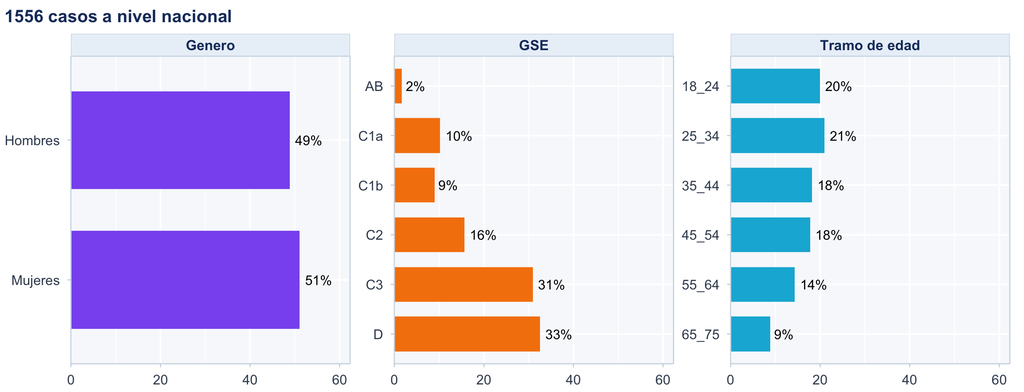

## Qué esperan las personas de una marca

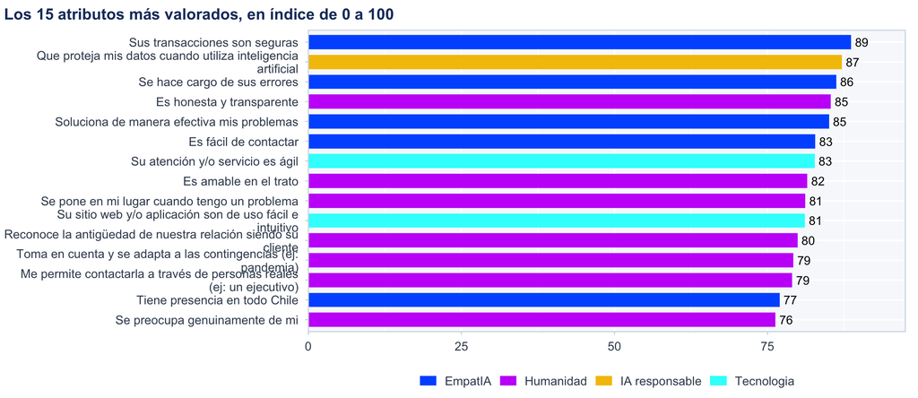

Cuanto mayor es el puntaje, mayor es la importancia que las personas atribuyen a esa característica. No es un porcentaje de personas.

## Alta expectativa de equilibrio

76%

cree que es importante que una marca sepa balancear la **cercanía** con la **tecnología**

85%

manifiesta alguna disposición a elegir marcas que equilibran las dos cosas

De esa disposición, **14%** aceptaría dedicar más tiempo y/o dinero, y **71%** lo elegiría solo si no implica un costo adicional.

Las respuestas distinguen interés sin costo adicional de disposición a dedicar más tiempo y/o dinero.

## Humanidad y tecnología: expectativa y preferencia

### Qué esperan

83%

espera marcas **cercanas**

63%

espera marcas **tecnológicas**

### Si hay que elegir

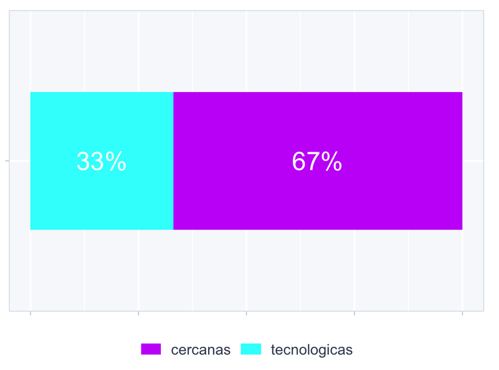

La primera lectura muestra qué se espera de las marcas; la segunda obliga a escoger entre cercanía y tecnología.

## A continuación, el ranking

## A quién se le preguntó por cada marca

Antes del ranking conviene saber una cosa del cuestionario, porque cambia cómo se leen todos los porcentajes que vienen: **nadie responde por todas las marcas**.

A cada persona se le sortea **una sola industria**, entre las que declara usar, y solo ve las marcas de esa industria. De las que dice conocer, se le pide evaluar **hasta quince**, elegidas de modo que todas las marcas del estudio terminen con una base de evaluación parecida: en esta edición, la marca mediana la evalúan 174 personas.

De ahí salen los dos denominadores del estudio:

**Cuántos la conocen**

Sobre las personas asignadas a su industria: alrededor de 389 por industria. No sobre la muestra completa, porque a las demás nunca se les preguntó por esa marca.

**Cuánto se le asocia un atributo**

Sobre las personas que la **conocen**: de cada cien que conocen la marca, cuántas le asocian el atributo.

El apéndice metodológico documenta el diseño completo.

## Cómo leer el ranking

El índice va de **0 a 100**. Combina cuánto se asocia una marca con cercanía y con tecnología entre quienes la conocen. Más puntos indican una mayor asociación; **el puesto no demuestra por sí solo una ventaja sobre la marca siguiente**. El dashboard permite revisar los márgenes y filtrar por público.

## El Índice EmpatIA promedio

10,8

es el Índice EmpatIA promedio de las 115 marcas del ranking 2026, con un margen de ±0,6 puntos. Cada marca cuenta una vez, sea muy o poco conocida: es la vara contra la que se puede leer el índice de cualquier marca.

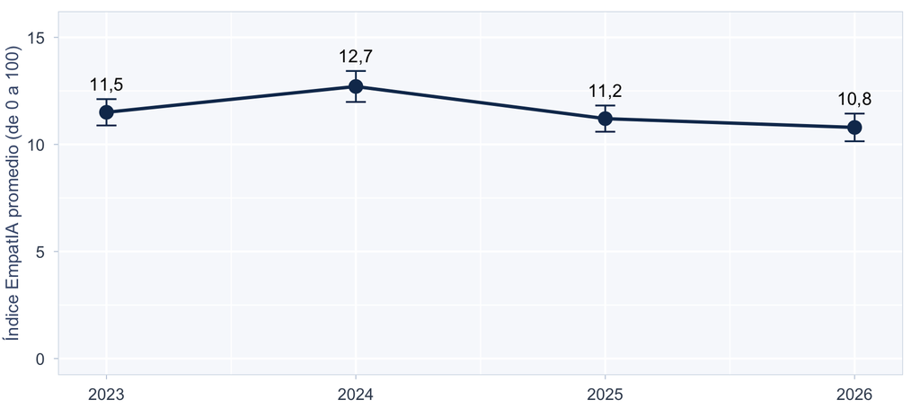

El promedio se mantiene respecto de 2025 (−0,4 puntos, dentro del margen de las dos encuestas), y se mantiene respecto de 2023 (−0,7 puntos, dentro del margen de las dos encuestas).

Cada edición promedia las marcas de su propio ranking (113 en 2023, 110 en 2024, 117 en 2025, 115 en 2026): parte de un cambio puede venir de marcas que entran o salen del listado. Cada punto es el índice publicado de su año, con sus ponderadores: 50% cercanía y 50% tecnología en 2023; 52,5% cercanía y 47,5% tecnología en 2024–2026.

## Top 30 — total industrias

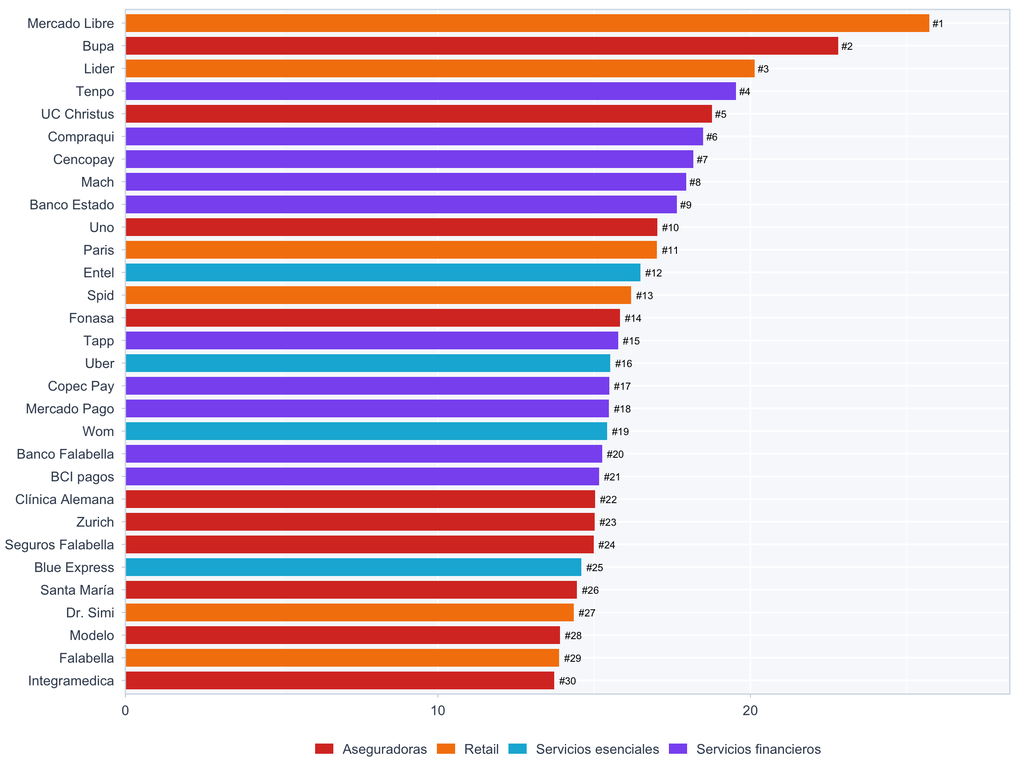

Índice EmpatIA: combinación de cercanía y tecnología.

## Top 10 por dimensión

### Cercanía

| # | Marca | Puntaje |
| --- | --- | --- |
| 1 | Dr. Simi | 21.8% |
| 2 | Lider | 21.4% |
| 3 | Mercado Libre | 20.9% |
| 4 | Banco Estado | 19.6% |
| 5 | Fonasa | 18.1% |
| 6 | Compraqui | 17.7% |
| 7 | Cencopay | 14.9% |
| 8 | Caja Vecina | 14.4% |
| 9 | Mach | 14.4% |
| 10 | Modelo | 14.2% |

### Tecnología

| # | Marca | Puntaje |
| --- | --- | --- |
| 1 | Bupa | 34.1% |
| 2 | Mercado Libre | 31.1% |
| 3 | Tenpo | 27.6% |
| 4 | Entel | 25.0% |
| 5 | UC Christus | 24.1% |
| 6 | Santa María | 24.0% |
| 7 | BCI pagos | 23.0% |
| 8 | Ali Express | 22.5% |
| 9 | Mach | 21.9% |
| 10 | Uno | 21.9% |

## Top 5 por industria

| # | Aseguradoras | Retail | Servicios esenciales | Servicios financieros |
| --- | --- | --- | --- | --- |
| 1 | Bupa | Mercado Libre | Entel | Tenpo |
| 2 | UC Christus | Lider | Uber | Compraqui |
| 3 | Uno | Paris | Wom | Cencopay |
| 4 | Fonasa | Spid | Blue Express | Mach |
| 5 | Clínica Alemana | Dr. Simi | Uber eats | Banco Estado |

## Primer lugar por categoría

| Industria | Categoria | Marca | Índice /100 |
| --- | --- | --- | --- |
| Aseguradoras | AFP | Uno | 17.0 |
| Aseguradoras | Isapres | Fonasa | 15.8 |
| Aseguradoras | Prestadores | Bupa | 22.8 |
| Aseguradoras | Seguros | Zurich | 15.0 |
| Retail | Farmacias | Dr. Simi | 14.3 |
| Retail | Food Service | Starbucks | 7.2 |
| Retail | Marketplace | Mercado Libre | 25.7 |
| Retail | Mejoramiento del hogar | Sodimac | 10.8 |
| Retail | Supermercados | Lider | 20.1 |
| Retail | Tiendas de conveniencia | Spid | 16.2 |
| Servicios esenciales | Delivery | Uber eats | 12.8 |
| Servicios esenciales | Distribución y logística | Blue Express | 14.6 |
| Servicios esenciales | Estaciones de servicio | Copec | 11.9 |
| Servicios esenciales | Internet y Telefonía | Entel | 16.5 |
| Servicios esenciales | Servicios básicos | Abastible | 10.2 |
| Servicios esenciales | Transporte | Uber | 15.5 |
| Servicios financieros | Bancos | Banco Estado | 17.7 |
| Servicios financieros | Cajas de Compensación | Los Héroes | 7.1 |
| Servicios financieros | Fintech | Tenpo | 19.5 |
| Servicios financieros | Servicios de pago | Compraqui | 18.5 |

## Cómo se ve cada marca

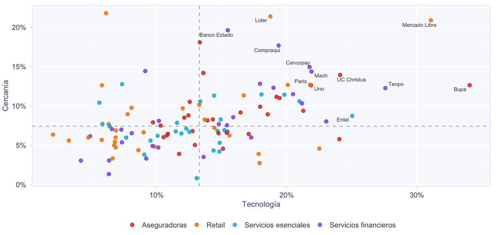

# Las personas y la inteligencia artificial

Hasta aquí el informe habló de marcas. Esta parte habla de las personas: cuántas usan inteligencia artificial de verdad, qué les preocupa, cómo quieren que las atiendan y qué eligen cuando hay que sacrificar algo.

Son las cifras que el estudio aporta al debate público, y por eso van con su margen a la vista: la barra fina sobre cada columna es el rango en que razonablemente cae el valor. Dos grupos cuyos rangos se pisan no son distintos, por más que sus barras lo parezcan.

## Qué piensan las personas de la IA

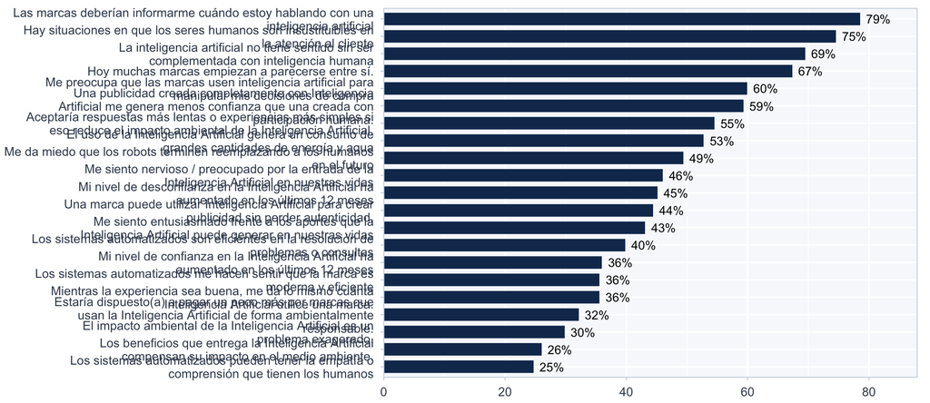

Porcentaje de personas de acuerdo con cada frase.

## Qué preocupa de la IA

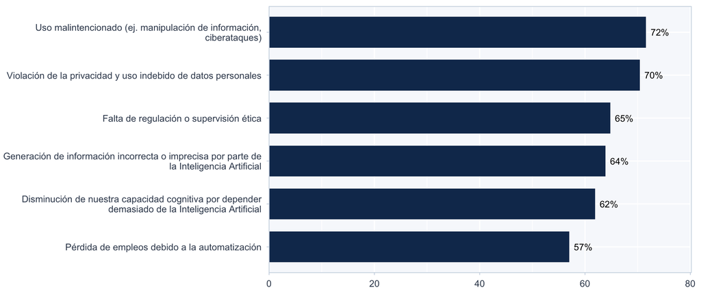

Porcentaje de personas preocupadas por cada situación.

## Se conoce casi universalmente; se usa mucho menos

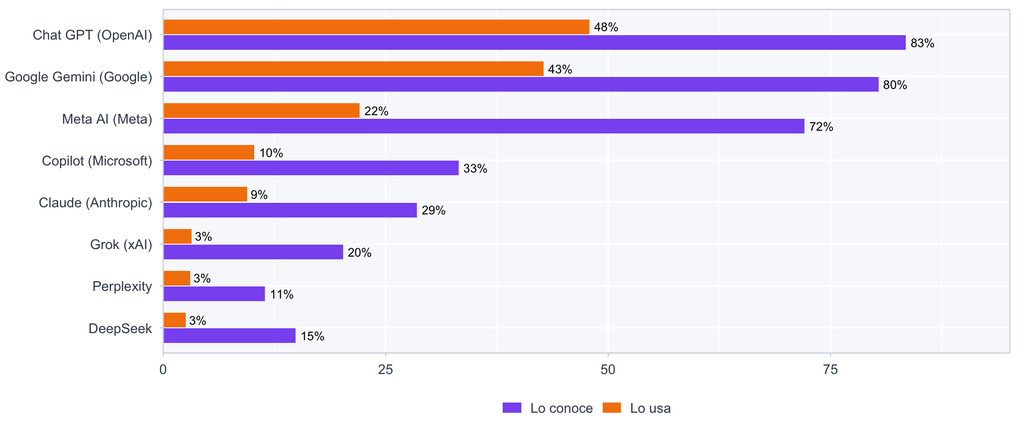

Las dos barras se leen **sobre la población**: de cada cien personas, cuántas conocen el asistente y cuántas lo usan al menos un par de veces al mes.

## Cuántas personas usan inteligencia artificial

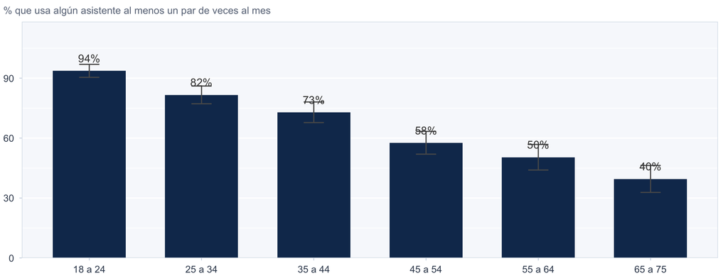

El **70%** de las personas usa algún asistente de inteligencia artificial al menos un par de veces al mes, y el **41%** usa dos o más. Conocerlos es casi universal —**95%** conoce alguno—, de modo que lo que separa a un grupo de otro ya no es el acceso sino el uso.

## Se usa y se desconfía a la vez

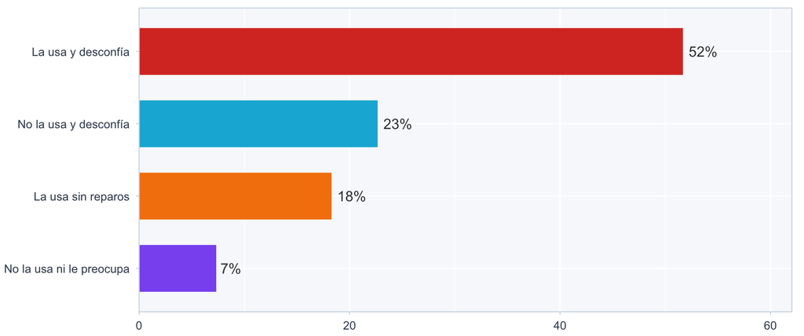

Se considera preocupada a la persona que declara inquietud alta en la mitad o más de los riesgos consultados. Usar y desconfiar no son opuestos: conviven en el grupo más numeroso.

## La paciencia con la máquina se acaba cuando hay un problema

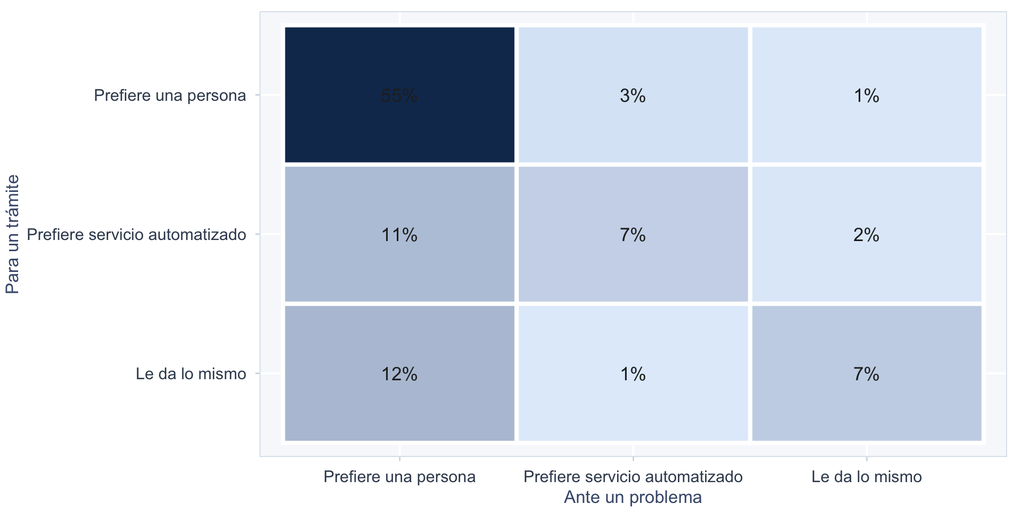

## Entre personalización y privacidad, gana la privacidad

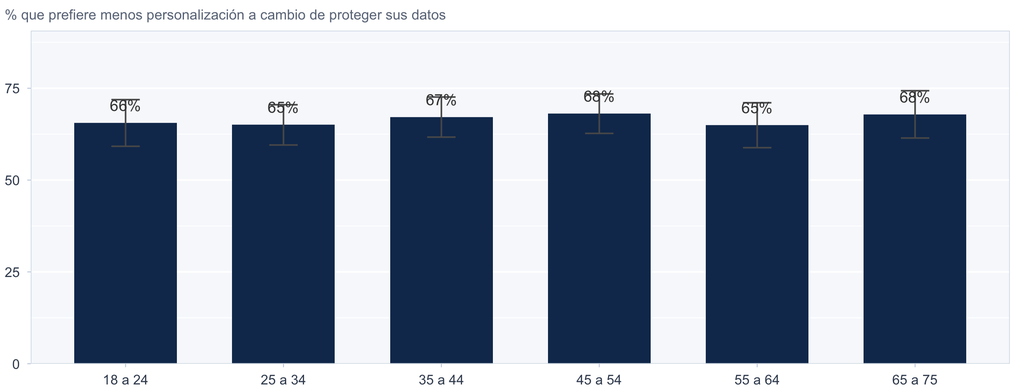

La pregunta obliga a elegir entre dos marcas y no admite punto medio. El **66%** elige la que protege sus datos. La preferencia no se quiebra por edad: ningún tramo se inclina por la personalización.

## El costo ambiental, y una contradicción a la vista

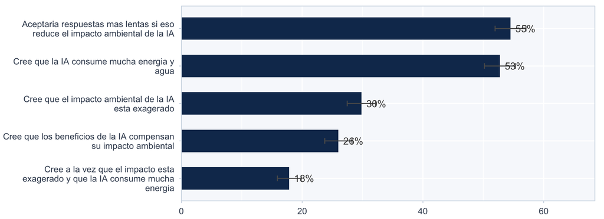

Las dos frases se refieren a lo mismo desde lados opuestos, y un **18%** está de acuerdo con las dos a la vez. No es un error de quien responde: es la señal de que la opinión sobre el costo ambiental de la inteligencia artificial todavía no está formada.

## Lo que esto le pide a las marcas

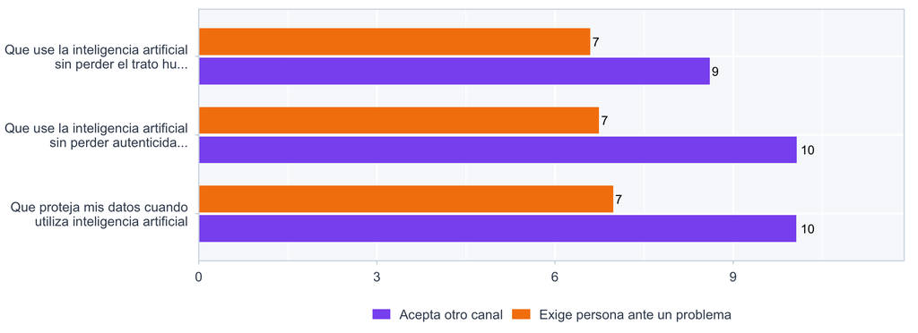

Quien exige ser atendido por una persona ve a las marcas peor que el resto en todos los atributos de IA responsable. Ahí es donde el debate público se vuelve una decisión de marca: no se trata de usar o no usar inteligencia artificial, sino de qué tan visible queda la persona detrás.

# Otros resultados

Esta parte del informe aborda las mismas preguntas con métodos distintos y agrega preguntas que el informe principal no responde. Cada resultado indica qué mide, qué margen tiene y qué implica para una marca. El desarrollo técnico está en el apéndice metodológico.

## Qué cambió respecto de las ediciones anteriores

**NotaCómo se lee un cambio**

Cada edición entrevista a personas distintas. Dos mediciones nunca dan exactamente lo mismo, aunque nada haya cambiado. Por eso un cambio solo se destaca cuando **supera el margen de las dos encuestas**: los cambios más chicos que ese margen se marcan como no concluyentes en vez de presentarse como una tendencia.

### La distancia entre lo humano y lo tecnológico

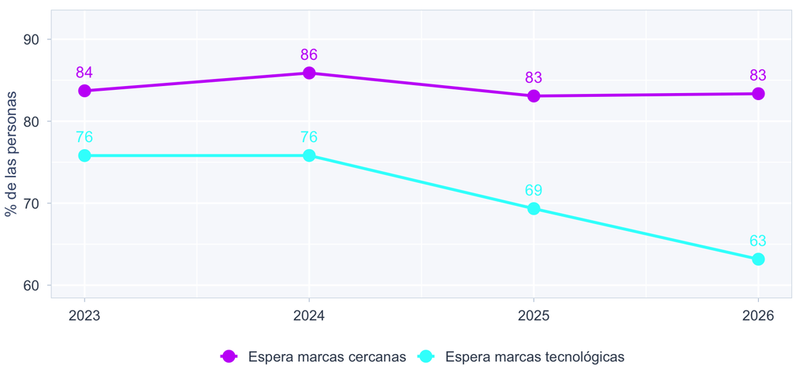

| Edición | Espera cercanas | Espera tecnológicas | Distancia | Margen |
| --- | --- | --- | --- | --- |
| 2023 | 83.7 | 75.8 | 7.9 | ± 2.7 |
| 2024 | 85.9 | 75.8 | 10.1 | ± 2.7 |
| 2025 | 83.1 | 69.3 | 13.7 | ± 2.9 |
| 2026 | 83.4 | 63.2 | 20.2 | ± 3.1 |

Desde 2023, la expectativa de marcas cercanas se mantiene (84% → 83%) y la de marcas tecnológicas cae (76% → 63%). **La distancia entre ambas crece edición tras edición**, y el cambio supera el margen de la encuesta.

Para una marca esto significa que la tecnología dejó de ser un diferenciador esperado por sí misma. Se sigue dando por supuesta, pero ya no es lo que se pide.

### Todos los cambios medidos

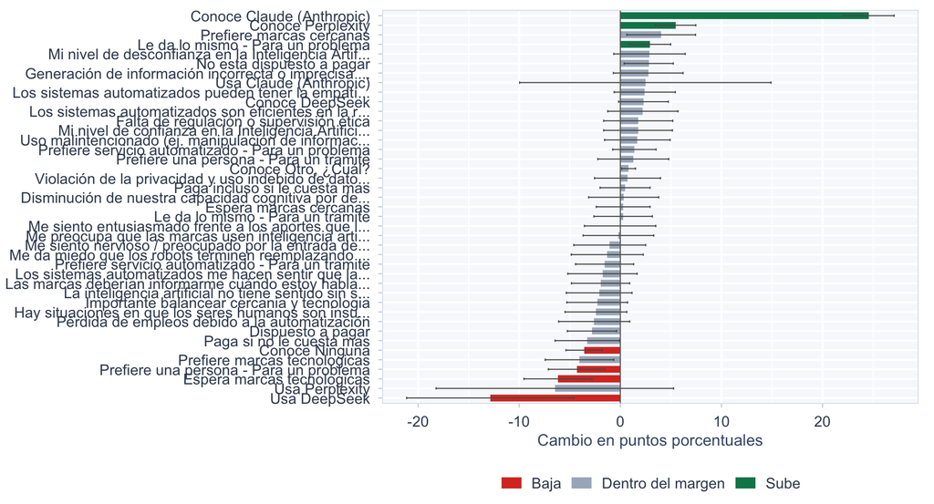

Las barras grises no son cambios pequeños: son diferencias que la encuesta **no permite afirmar**. Las líneas indican el margen de cada cambio.

| Indicador | Antes | Ahora | Cambio | Margen |
| --- | --- | --- | --- | --- |
| Conoce Claude (Anthropic) | 3.9 | 28.5 | 24.6 | ± 2.5 |
| Usa DeepSeek | 29.8 | 16.9 | -12.9 | ± 8.3 |
| Espera marcas tecnologicas | 69.3 | 63.2 | -6.2 | ± 3.4 |
| Conoce Perplexity | 6.0 | 11.4 | 5.5 | ± 2 |
| Prefiere una persona - Para un problema | 82.9 | 78.6 | -4.3 | ± 2.8 |
| Conoce Ninguna | 8.8 | 5.2 | -3.6 | ± 1.8 |
| Le da lo mismo - Para un problema | 7.8 | 10.7 | 2.9 | ± 2.1 |

### Qué historia cuentan juntos

Los cambios respaldados desde 2023 no son independientes entre sí. Leídos en conjunto describen un movimiento coherente: **las personas le atribuyen más capacidad a la inteligencia artificial y, al mismo tiempo, le temen más.**

- Sube el acuerdo con «Los sistemas automatizados pueden tener la empatía o comprensión que tienen los humanos» (15% → 25%).
- Sube el acuerdo con «Los sistemas automatizados son eficientes en la resolución de problemas o consultas» (33% → 40%).
- Sube el acuerdo con «Me da miedo que los robots terminen reemplazando a los humanos en el futuro» (44% → 49%).
- Baja el acuerdo con «Hay situaciones en que los seres humanos son insustituibles en la atención al cliente» (85% → 75%).
- Baja el acuerdo con «La inteligencia artificial no tiene sentido sin ser complementada con inteligencia humana» (74% → 69%).

Para una marca, la implicancia es concreta: **la automatización ya no necesita justificarse por su capacidad, sino por su intención**. Lo que se cuestiona no es si la tecnología funciona, sino para qué se está usando.

### Cómo se movieron las marcas

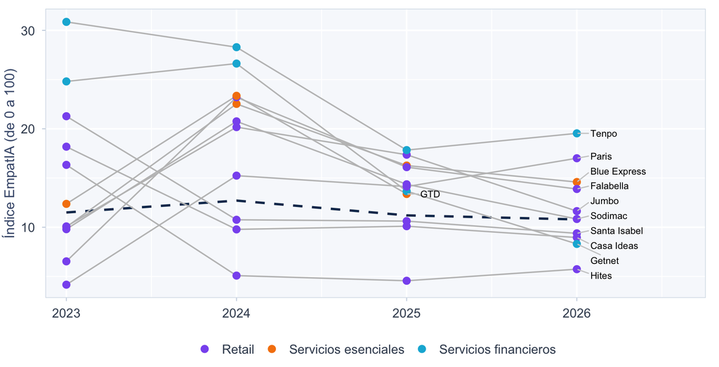

Las marcas con los cambios más grandes entre dos ediciones consecutivas, con el Índice EmpatIA publicado de cada año. La línea punteada es el promedio del estudio de cada edición.

El dashboard permite ver esta trayectoria para cualquier marca y público. El apéndice detalla cómo se calcula el margen de un cambio entre dos encuestas independientes.

## ¿Y si el índice usara todos los atributos?

El Índice EmpatIA combina dos atributos. El estudio mide 28. La pregunta natural es si usar todos mejora la medición, y la única forma honesta de responderla es comparar contra algo que ninguno de los índices use para construirse: **la preferencia declarada**.

Se compararon cuatro formas de resumir una marca en un número.

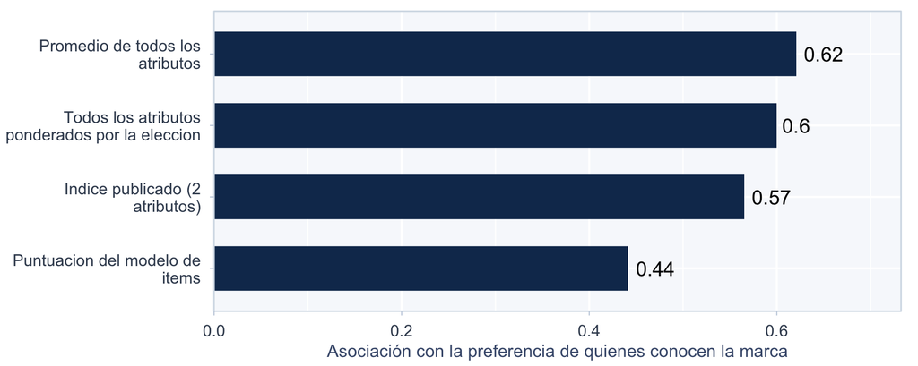

**El promedio simple de todos los atributos se asocia más con la preferencia que el índice actual** (0,62 frente a 0,57). Ponderar esos atributos por cuánto pesa cada uno en la elección no agrega nada por sobre el promedio simple.

La cuarta alternativa —una puntuación estimada con un modelo de medición— queda muy por detrás. Es un resultado esperable una vez que se entiende por qué: esa puntuación está pensada para ordenar evaluaciones individuales, y al promediarla dentro de una marca se comprimen justamente las diferencias entre marcas. Se documenta porque descartar una alternativa con evidencia también es un resultado.

**NotaCómo leerlo**

Un valor más alto significa que el índice ordena a las marcas de forma más parecida a como las ordena la preferencia de las personas. No significa que subir el índice cause preferencia.

## ¿Cuántas cosas distintas miden en realidad los 28 atributos?

Antes de decidir cómo combinarlos conviene saber si miden una sola cosa o varias.

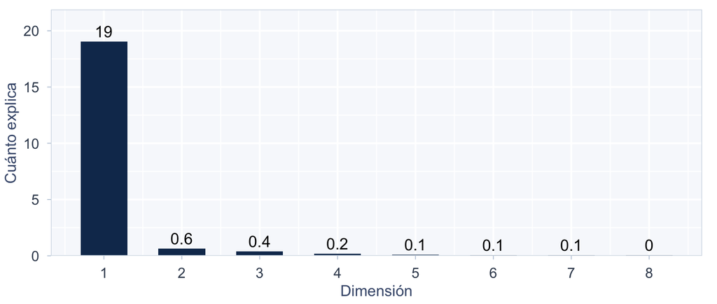

La primera dimensión explica 19,0 y la segunda 0,65. La diferencia es enorme: **los 28 atributos miden esencialmente una sola cosa**. Cuando una marca es bien evaluada, tiende a serlo en todos los atributos a la vez.

Una sola dimensión da cuenta del 68% de lo que los atributos tienen en común.

Esto tiene dos consecuencias prácticas. La primera es que promediarlos todos es defendible: no se están mezclando cosas ajenas. La segunda es más incómoda: **las diferencias entre bloques son mucho menores de lo que sugiere tratarlos como cuatro territorios separados.**

## Cuáles atributos distinguen y cuáles no

Que todos midan lo mismo no significa que todos sirvan igual. Algunos separan nítidamente a las marcas bien evaluadas de las demás; otros los marca casi cualquiera.

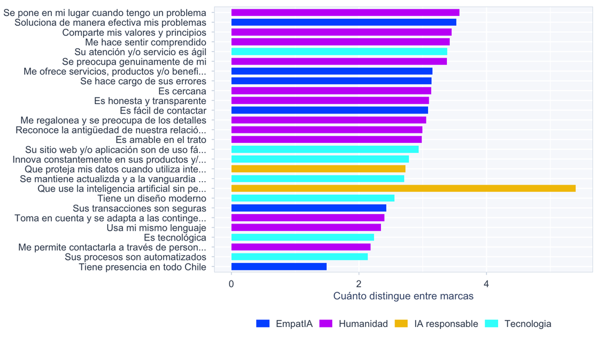

## Qué pasaría con el ranking

Cambiar la fórmula no es neutro. Estas son las marcas cuyo puesto más cambiaría si el índice pasara a usar todos los atributos.

| Marca | Industria | Puesto actual | Puesto con todos | Cambio |
| --- | --- | --- | --- | --- |
| Temu | Retail | 56 | 86 | -30 |
| Scotiabank | Servicios financieros | 90 | 61 | 29 |
| Consalud | Aseguradoras | 62 | 90 | -28 |
| Aramco | Servicios esenciales | 63 | 89 | -26 |
| Farmacias Ahumada | Retail | 109 | 83 | 26 |
| Habitat | Aseguradoras | 76 | 53 | 23 |
| Cruz Blanca | Aseguradoras | 85 | 108 | -23 |
| Chilexpress | Servicios esenciales | 86 | 66 | 20 |
| Banmedica | Aseguradoras | 75 | 95 | -20 |
| Cabify | Servicios esenciales | 61 | 80 | -19 |

Las marcas que bajan son, en general, las que destacan en cercanía o tecnología pero no en el resto de la experiencia. **Es una decisión de definición, no solo de método**: hay que resolver primero qué debe medir el índice.

## Fortalezas y debilidades frente a la industria

Para cada marca y cada público, la diferencia contra el promedio de las **otras** marcas de su industria. El color solo aparece cuando la diferencia supera el margen de la encuesta.

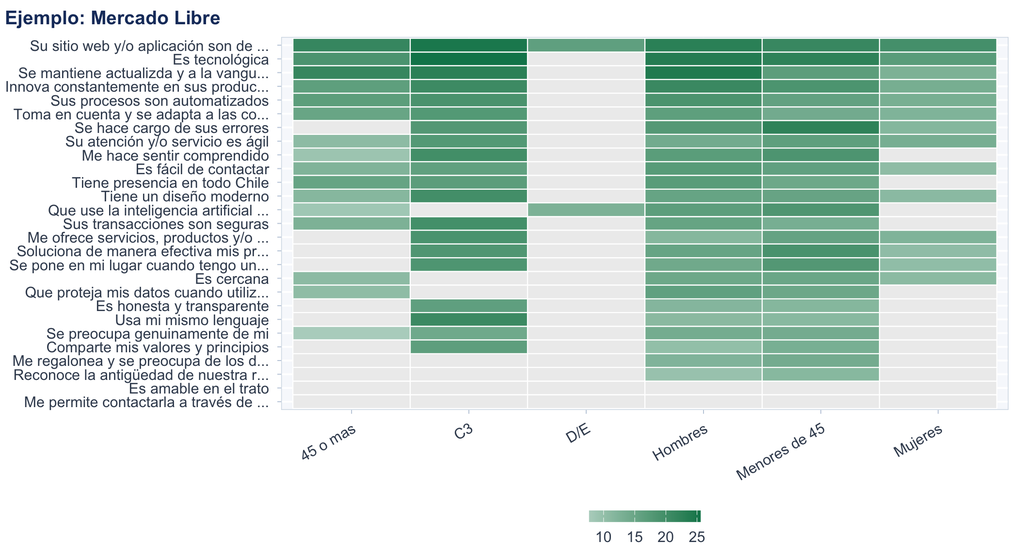

Solo el 13% de las celdas del estudio supera su propio margen. **Las celdas grises no son diferencias pequeñas: son diferencias que la encuesta no permite afirmar.**

## Lo que ese mapa realmente contiene

Al mirar la matriz completa uno busca patrones por público. La pregunta previa es cuánto de lo que se ve es el perfil de la marca, igual en todas partes, y cuánto es propio de un público.

Al separar ambas cosas, el perfil común explica el 80% del mapa típico, y en 80 de 105 marcas apunta en la misma dirección en todos los públicos.

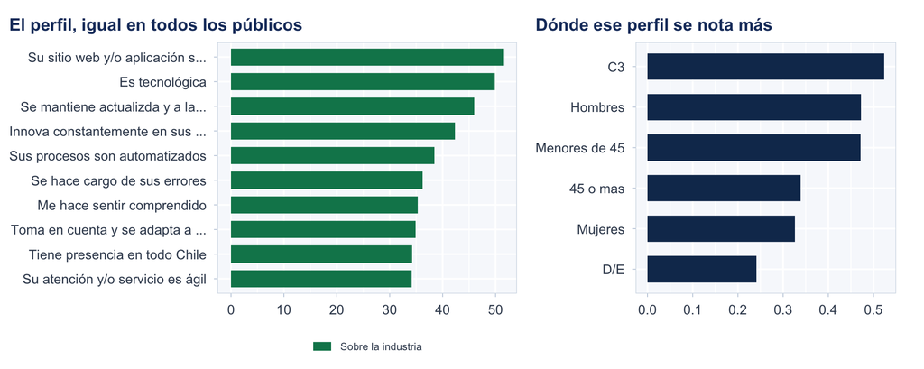

**Para la empresa esto significa que la conversación es sobre el perfil, no sobre cada casilla.** Lo específico de un público es el 20% del mapa, y la diferencia típica de un público (3,1 puntos) no alcanza su margen (5,5 puntos).

## Perfiles de personas que las segmentaciones habituales no ven

Género, edad y grupo socioeconómico son cortes cómodos, pero ajenos a lo que el estudio mide. La pregunta aquí es si las personas se agrupan por **lo que miran** al evaluar una marca.

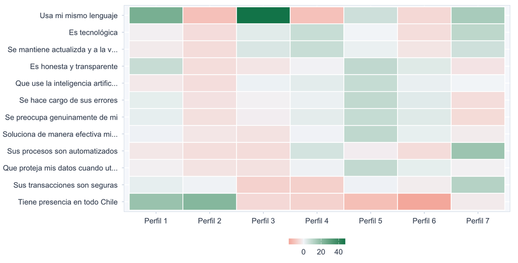

| Perfil | Personas | % del mercado | Certeza de asignación |
| --- | --- | --- | --- |
| 1 | 76 | 5.7 | 0.83 |
| 2 | 365 | 27.3 | 0.90 |
| 3 | 66 | 4.9 | 0.86 |
| 4 | 195 | 14.6 | 0.75 |
| 5 | 99 | 7.4 | 0.73 |
| 6 | 351 | 26.3 | 0.62 |
| 7 | 185 | 13.8 | 0.79 |

Se encontraron **7 perfiles**. Estimados por separado en dos mitades independientes de la muestra, separan a las mismas personas un **34%** por sobre lo que daría el azar.

**No son los cortes de siempre.** Su asociación con género, generación y grupo socioeconómico llega como máximo a **0.12** en una escala de 0 a 1: estos perfiles **cruzan** las categorías demográficas.

Tampoco son tribus separadas. Un método que busca huecos de densidad deja al **78%** de las personas sin grupo: el mercado es un continuo, y estos perfiles son cortes útiles dentro de él, no islas.

El dashboard muestra, para cualquier marca, qué perfiles la conocen y la prefieren más de lo esperable por su tamaño.

## Con quién compite de verdad cada marca

Si se comparan las marcas por sus 28 puntajes tal cual, lo que domina es el tamaño: una marca conocida puntúa alto en todo. Para hablar de posicionamiento importa la **forma** del perfil: en qué se destaca cada marca respecto de sí misma.

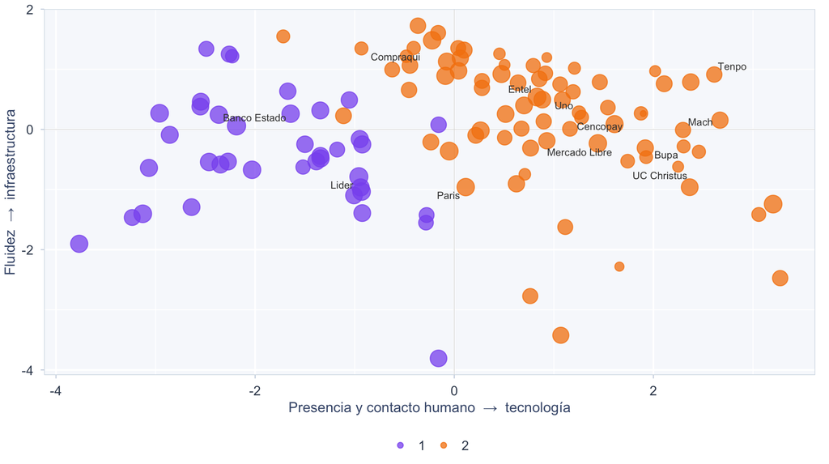

El agrupamiento **no reproduce la industria**: usando la industria como criterio, la separación es de 0.026, prácticamente nula. Una farmacia y un banco pueden estar parados igual, y dos bancos en extremos opuestos.

**Implicancia directa: la competencia por posicionamiento no es la que aparece en la categoría.** El dashboard permite ver, para cada marca, cuáles son sus vecinas reales en este mapa.

## Qué tan estable es todo esto

Un resultado que no reaparece con otras personas no sirve para decidir. Cada análisis de esta sección se sometió a la misma prueba: construirlo con una mitad de la muestra y evaluarlo en la otra.

| Cantidad de grupos | Coincidencia entre mitades | Separación en la otra mitad | ¿Suficientemente estable? |
| --- | --- | --- | --- |
| 2 | 0.21 | 0.12 | No |
| 3 | 0.17 | 0.07 | No |
| 4 | 0.15 | 0.05 | No |
| 5 | 0.14 | 0.04 | No |
| 6 | 0.13 | 0.04 | No |

Cuando ninguna partición alcanza el umbral, la lectura correcta es que **el mercado se comporta como un continuo y no como un conjunto de segmentos separados**. Forzar grupos en ese caso produce etiquetas que no reaparecen en la siguiente medición.

## Del conocimiento a la preferencia

Conocer una marca, comprarla y preferirla son tres cosas distintas. La distancia entre ellas dice dónde se pierde una marca: puede ser muy conocida y poco preferida, o al revés.

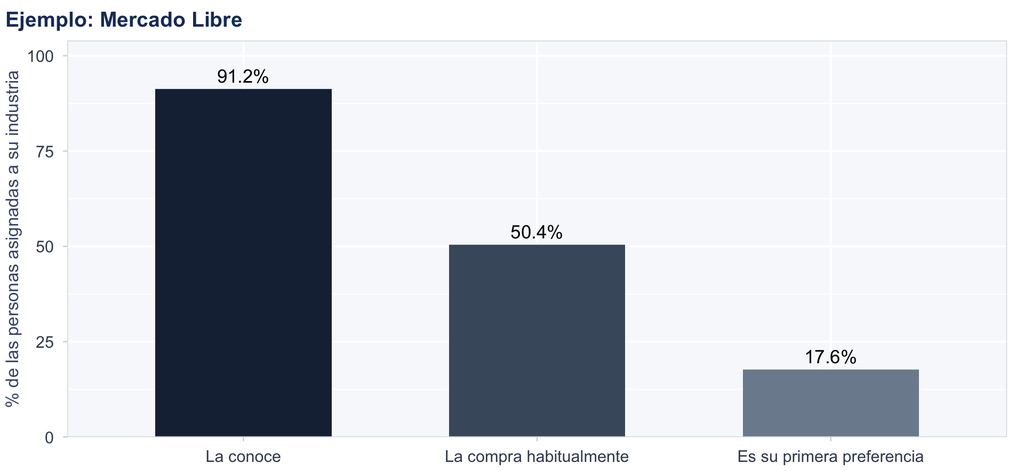

**NotaCómo leerlo**

Las tres cifras son sobre **el mismo total de personas**, así que son comparables entre sí. Una persona puede conocer y comprar varias marcas; la primera preferencia corresponde a una sola. No se supone que quien compra también prefiere: cada etapa se cuenta como fue declarada.

El dashboard muestra este recorrido para cualquier marca y público.

## La marca no es la misma en todos los públicos

El índice de una marca cambia según a quién se le pregunte. Esa variación es información: señala dónde la marca ya funciona y dónde tiene terreno por ganar.

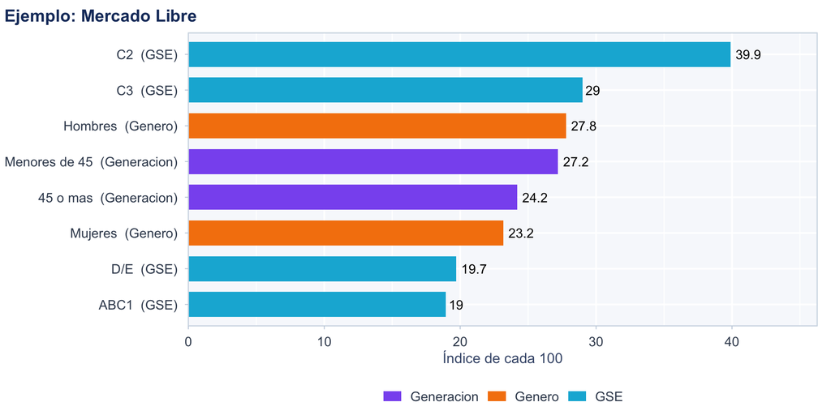

Los públicos de distintas clasificaciones **contienen a las mismas personas**: alguien puede estar a la vez en «Mujeres», «Menores de 45» y «C2». No son grupos excluyentes, y sus cifras no se suman.

Cuando menos de 60 casos efectivos de un público conocen la marca, no se publica un puesto: la cifra sería demasiado inestable para interpretarla.

## Escenarios: dónde hay más preferencia en juego

Para cada atributo que la marca todavía no tiene asociado, el modelo estima cuánta preferencia está asociada a conseguirlo.

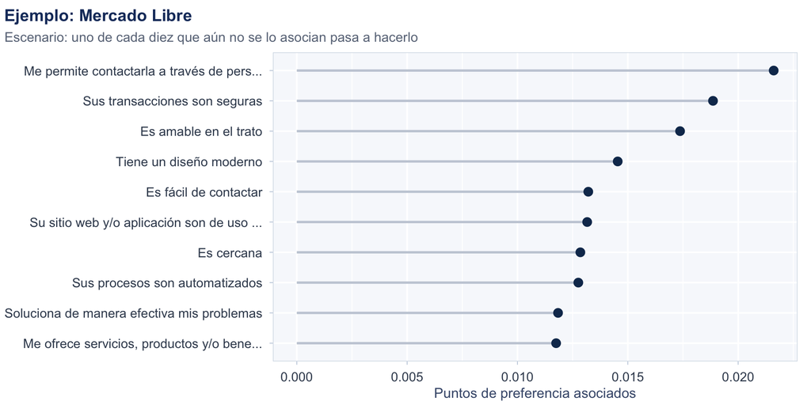

**ImportanteQué es y qué no es**

Es un **escenario de asociación**, no una proyección de retorno. Describe cuánta preferencia está asociada a ese atributo entre quienes ya se lo atribuyen a la marca; no afirma que invertir en él producirá esa ganancia.

La razón está en la sección del modelo: la asociación entre percepción y preferencia es mayormente simultánea, y la parte que anticipa al año siguiente es pequeña.

El dashboard permite elegir la marca, el público y qué proporción de personas cambia de opinión en el escenario.

## Qué se asocia con la preferencia

Los atributos siguientes son los que muestran mayor asociación con la preferencia en esta edición. Sirven para orientar preguntas de negocio y contrastarlas con la situación de cada marca. **No equivalen al retorno que tendría invertir en ellos.**

| Atributo | Lectura |
| --- | --- |
| Sus transacciones son seguras | Asociación respaldada |
| Su sitio web y/o aplicación son de uso fácil e intuitivo | Asociación respaldada |
| Tiene un diseño moderno | Asociación respaldada |
| Sus procesos son automatizados | Asociación respaldada |
| Es cercana | Asociación respaldada |
| Tiene presencia en todo Chile | Asociación respaldada |
| Es amable en el trato | No concluyente |
| Es tecnológica | No concluyente |

## Qué tan útil resulta anticipar la preferencia

Cada cifra indica en cuántas de cada 100 personas se acertó la marca preferida sin usar sus respuestas para ajustar el modelo. Se comparan las mismas personas y las mismas marcas disponibles para cada una.

| Criterio | Aciertos de cada 100 | Margen desde | Margen hasta |
| --- | --- | --- | --- |
| Azar | 10.1 | 9.6 | 10.6 |
| Indice EmpatIA | 24.7 | 21.6 | 27.8 |
| Marca mas conocida | 22.2 | 19.4 | 25.3 |
| Modelo de eleccion | 51.0 | 47.2 | 54.6 |

Esto evalúa preferencias declaradas dentro de la encuesta. No demuestra que se puedan anticipar ventas futuras. El apéndice documenta cómo se hizo la prueba.

## Dos atributos para el índice; cuatro bloques para leer la experiencia

El **Índice EmpatIA** combina dos atributos concretos: **«Es cercana»** y **«Es tecnológica»**.

Los 28 atributos del estudio se organizan además en bloques:

| Bloque | Qué reúne | Atributos |
| --- | --- | --- |
| Humanidad | Trato, comprensión y relación con las personas | 12 |
| Tecnología | Agilidad, herramientas digitales e innovación | 7 |
| EmpatIA | Seguridad, personalización, resolución, respuesta a errores, contacto y cobertura | 6 |
| IA responsable | Uso de inteligencia artificial sin perder autenticidad, trato humano ni resguardo de los datos | 3 |

Estos bloques ya aparecen en el informe público original. **No son componentes del índice.** El bloque EmpatIA y el índice tienen el mismo nombre, pero representan conceptos distintos. El bloque **IA responsable** reúne los tres atributos que se incorporan en 2026: se mantiene aparte para que los otros tres bloques sigan siendo comparables con las ediciones anteriores, y no entra en el índice.

Comparar la asociación de estos bloques con los pesos de la fórmula **no permite concluir que la tecnología esté sobreponderada**. Cualquier cambio del índice requiere definir primero qué debe medir y validar después la alternativa.

## Un modelo de la preferencia en el tiempo

Las secciones anteriores describen. Esta pregunta otra cosa: **dado cómo perciben a una marca, cuánta gente la conoce, en qué industria está y en qué año se mide, ¿qué preferencia cabe esperar?**

La distancia entre lo que una marca logra y lo que el modelo espera de ella es información accionable: señala si está convirtiendo su percepción en preferencia mejor o peor de lo que su situación permitiría.

**NotaCómo está construido**

La preferencia es una proporción con denominador conocido: de quienes conocen la marca, cuántos la ponen primera. Se modela como tal, de modo que una marca con base pequeña pesa menos sin necesidad de ponderarla a mano.

Las marcas están dentro de industrias, y ambos niveles tienen variación propia. El modelo estima un término para cada marca y para cada industria: las marcas con poca información se acercan al promedio de su industria en lugar de producir estimaciones extremas.

### Dónde está cada marca frente a lo esperado

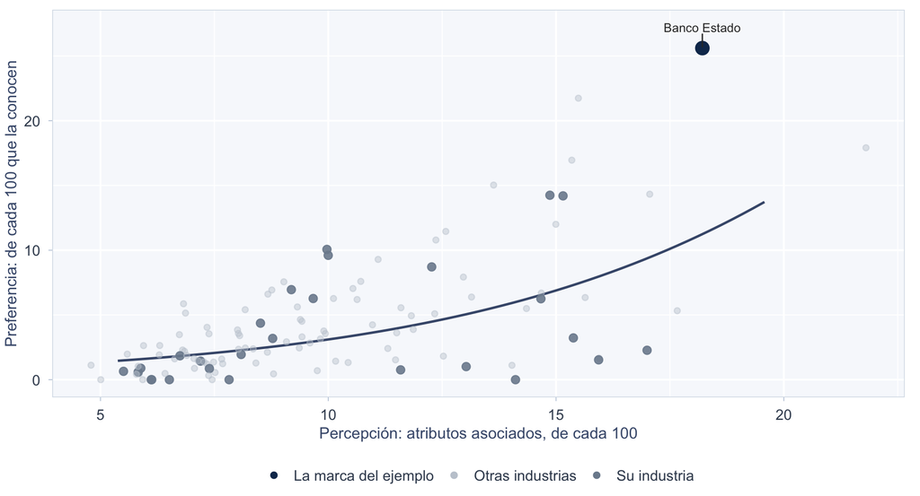

La línea es lo que el modelo espera según la percepción. **Estar por encima significa lograr más preferencia de la que corresponde a esa percepción**; por debajo, lo contrario.

El dashboard permite elegir cualquier marca y ver esta misma lámina con ella destacada, comparada contra su industria y contra el resto.

### Qué pesa en la preferencia

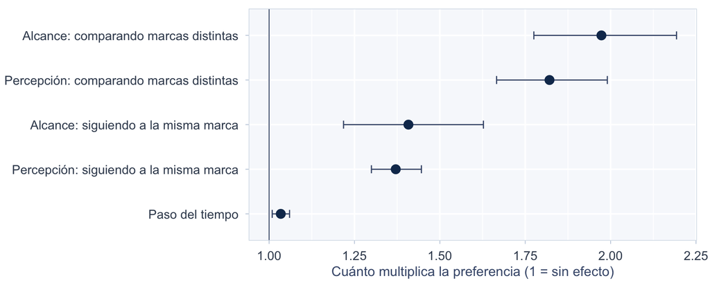

El modelo separa dos preguntas que suelen confundirse:

- **Comparando marcas distintas**, una desviación estándar más de percepción multiplica la preferencia por **1.82**.
- **Siguiendo a la misma marca en el tiempo**, la misma mejora la multiplica por **1.37**.

El segundo es el relevante para decidir, y es menor que el primero. Parte de lo que distingue a las marcas mejor percibidas no se mueve al mejorar la percepción: es historia acumulada, tamaño o posición que el atributo no captura.

### Qué tan firme es el resultado

| Prueba | Efecto estimado | Observaciones |
| --- | --- | --- |
| Modelo principal | 0.315 | 455 |
| Remuestreo de marcas (mediana) | 0.336 | 40 |
| Percepcion del ano anterior | 0.045 | 320 |
| Solo marcas con base holgada | 0.367 | 433 |

El efecto se estimó de cuatro maneras: el modelo principal, remuestreando marcas completas, usando la percepción del **año anterior** en vez de la del mismo año, y restringiendo a marcas con base holgada.

El modelo principal, el remuestreo y las bases holgadas coinciden. La percepción del año anterior da un efecto mucho menor (0,05 frente a 0,32).

**Buena parte de la asociación es simultánea**: se mide en la misma encuesta. La parte que anticipa al año siguiente es pequeña.

**ImportanteQué significa esto para una decisión**

El modelo describe asociación, no efecto causal. Sirve para saber **dónde está una marca respecto de lo esperable** y para ordenar hipótesis, no para prometer que una inversión en percepción producirá un retorno determinado en preferencia.

## Cómo usar estos resultados en una reunión de marca

1. Revisar índice, base y competidores del mismo público.
2. Identificar atributos con diferencias respaldadas frente a otras marcas de la industria.
3. Contrastar esas diferencias con lo que se asocia a la preferencia.
4. Usar los escenarios como hipótesis para diseñar pruebas; medir su resultado antes de comprometer un retorno.

El dashboard ofrece selección de marca, comparación, públicos, escenarios y evolución. Los mapas exploratorios, pruebas estadísticas, fórmulas y decisiones metodológicas están en el **apéndice metodológico**.